# Challenge MIMSE 2014

Adrien Todeschini

Bienvenue sur la page du challenge d’[Apprentissage automatique](https://adrtod.github.io/ml2014) du Master 2 [MIMSE](http://www.math.u-bordeaux.fr/DIM/master/mimse/pageweb/pmwiki.php) !

| **342** | **8** | **✔** |
| --- | --- | --- |
| soumissions | équipes | terminé |

Dernière mise à jour : `08 janv. 2015 00:00`

# News

**Le 8 janv. 2015 :**

Le challenge est terminé et voici le classement final. Bravo à tous !

**Le 3 nov. 2014 :**

Les scores sont maintenant calculés sur l’ensemble du jeu test et non plus sur un sous ensemble. Le classement et l’historique ont été mis à jour en conséquence. La date limite des contributions a été repoussée au mercredi 07 janv. 2015.

**Le 7 oct. 2014 :**

Le challenge est ouvert !

Meilleur taux d’erreur

| Classement | Equipe | Soumissions | Date | Taux d’erreur | Coût moyen |
| --- | --- | --- | --- | --- | --- |
| 1. | CLF_KH_VG | 58 | 07/01/15 16:12 | 0.220 | 0.740 |
| 2. | CC_JC_CD | 55 | 07/01/15 15:38 | 0.220 | 0.760 |
| 3. | GB_AD_BH | 60 | 07/01/15 19:50 | 0.225 | 0.865 |
| 4. | Anonymous | 25 | 18/11/14 16:55 | 0.225 | 0.925 |
| 5. | MP_DS_BT | 35 | 31/12/14 13:20 | 0.230 | 0.790 |
| 6. | FCS_CS_CD | 40 | 07/01/15 18:40 | 0.230 | 0.910 |
| 7. | CA_IB_YQ | 20 | 28/12/14 15:17 | 0.235 | 0.755 |
| 8. | DZ_JK_MG | 49 | 05/01/15 11:35 | 0.275 | 1.175 |
| 9. | baseline | 6 | 07/10/14 16:28 | 0.300 | 1.500 |

Meilleur coût moyen

| Classement | Equipe | Soumissions | Date | Coût moyen | Taux d’erreur |
| --- | --- | --- | --- | --- | --- |
| 1. | DZ_JK_MG | 49 | 06/01/15 09:26 | 0.460 | 0.420 |
| 2. | CA_IB_YQ | 20 | 05/01/15 17:36 | 0.525 | 0.405 |
| 3. | CLF_KH_VG | 58 | 07/01/15 22:34 | 0.550 | 0.490 |
| 4. | MP_DS_BT | 35 | 03/01/15 02:45 | 0.570 | 0.490 |
| 5. | Anonymous | 25 | 17/10/14 17:21 | 0.615 | 0.255 |
| 6. | baseline | 6 | 07/10/14 16:28 | 0.700 | 0.700 |
| 7. | CC_JC_CD | 55 | 07/01/15 22:46 | 0.700 | 0.700 |
| 8. | FCS_CS_CD | 40 | 07/01/15 22:44 | 0.775 | 0.255 |
| 9. | GB_AD_BH | 60 | 07/01/15 13:52 | 0.850 | 0.230 |

# Objectif

**Classification binaire** : prédire la solvabilité ou le risque de non-remboursement d’un ensemble de clients dans le but de l’octroi de crédit bancaire.

On dispose pour cela d’un jeu de données d’apprentissage supervisé : ensemble de clients dont la réponse est connue. Le but est d’obtenir le meilleur score de prédiction sur un jeu de données test dont la réponse est cachée.

# Déroulement du challenge

1. Envoyer un email à adrien.todeschini@inria.fr contenant les informations suivantes :
   - nom de l’équipe et des participants
   - au moins une adresse email associée à un compte Dropbox
2. Vous recevrez une invitation à partager un dossier Dropbox portant le nom de votre équipe.
3. Télécharger les données.
4. Soumettre vos prédictions sur le jeu test sous format csv dans le dossier Dropbox partagé.
- **Note** : Le nombre de soumissions n’est pas limité. Cependant le calcul des scores n’est mis à jour que toutes les heures.
- **Date limite des soumissions** : mercredi 07 janv. 2015 23:59 CET

# Description des données

| Nom | Fichier | Description | Liens |
| --- | --- | --- | --- |
| Apprentissage | `data_train.rda` | `data.frame` avec `800` lignes/clients et `21` colonnes/variables |  |
| Test | `data_test.rda` | `data.frame` avec `200` lignes/clients et `20` colonnes/variables |  |

Ces fichiers sont à importer dans R avec :

```r
load("data_train.rda")
load("data_test.rda")
```

La variable à prédire est la variable `Class` dont la valeur est `Bad` ou `Good`. Les valeurs d’apprentissage de cette variable sont fournies dans la dernière colonne de `data_train`. `data_test` ne contient pas cette colonne puisqu’elle doit être prédite.

Le jeu de données complet contient 30% de `Bad` et 70% de `Good`. Ces proportions sont respectées à la fois dans le jeu d’apprentissage et le jeu test.

```r
table(data_train$Class)/nrow(data_train)
```

```
##
##  Bad Good
##  0.3  0.7
```

Pour la prédiction, on dispose de `20` variables explicatives dont :

- `7` variables quantitatives de classe `numeric`
- `13` variables qualitatives de classe `factor`

```r
str(data_test)
```

```
## 'data.frame':    200 obs. of  20 variables:
##  $ Duration                 : num  24 48 45 36 36 42 24 18 12 18 ...
##  $ Amount                   : num  4870 4308 4746 2225 1977 ...
##  $ InstallmentRatePercentage: num  3 3 4 4 4 4 1 2 2 4 ...
##  $ ResidenceDuration        : num  4 4 2 4 4 3 1 4 4 2 ...
##  $ Age                      : num  53 24 25 57 40 34 44 39 20 33 ...
##  $ NumberExistingCredits    : num  2 1 2 2 1 1 2 2 1 1 ...
##  $ NumberPeopleMaintenance  : num  2 1 1 1 1 1 1 2 1 1 ...
##  $ Telephone                : Factor w/ 2 levels "none","yes": 2 2 2 1 1 2 1 1 2 2 ...
##  $ ForeignWorker            : Factor w/ 2 levels "no","yes": 2 2 2 2 2 2 2 2 2 2 ...
##  $ CheckingAccountStatus    : Factor w/ 4 levels "lt.0","0.to.200",..: 1 1 2 2 1 1 4 4 1 1 ...
##  $ CreditHistory            : Factor w/ 5 levels "NoCredit.AllPaid",..: 4 3 5 4 3 3 3 2 3 3 ...
##  $ Purpose                  : Factor w/ 11 levels "NewCar","UsedCar",..: 1 10 4 1 7 4 4 1 3 3 ...
##  $ SavingsAccountBonds      : Factor w/ 5 levels "lt.100","100.to.500",..: 1 1 1 1 5 1 5 1 1 1 ...
##  $ EmploymentDuration       : Factor w/ 5 levels "lt.1","1.to.4",..: 2 1 1 4 4 1 1 4 2 5 ...
##  $ Personal                 : Factor w/ 5 levels "Male.Divorced.Seperated",..: 3 2 3 3 3 3 2 3 2 2 ...
##  $ OtherDebtorsGuarantors   : Factor w/ 3 levels "None","CoApplicant",..: 1 1 1 1 1 1 1 1 1 1 ...
##  $ Property                 : Factor w/ 4 levels "RealEstate","Insurance",..: 4 2 2 4 4 3 3 4 3 3 ...
##  $ OtherInstallmentPlans    : Factor w/ 3 levels "Bank","Stores",..: 3 3 3 1 3 3 3 1 3 3 ...
##  $ Housing                  : Factor w/ 3 levels "Rent","Own","ForFree": 3 1 2 3 2 2 2 2 1 2 ...
##  $ Job                      : Factor w/ 4 levels "UnemployedUnskilled",..: 3 3 2 3 4 3 3 4 3 3 ...
```

Les statistiques univariées de ces variables peuvent facilement être obtenues :

```r
summary(rbind(data_train[,-ncol(data_train)], data_test))
```

[output not shown]

# Prédiction

Un classifieur est une fonction qui affecte une classe `Bad` ou `Good` à l’ensemble des données test. Un telle fonction peut être :

```r
predict_all_good <- function(data_test, ...) {
  y_pred = rep("Good", nrow(data_test))
  return(y_pred)
}
```

```r
y_pred = predict_all_good(data_test)
```

Vous devez programmer un ou plusieurs classifieurs qui utilisent les données d’apprentissage pour améliorer les performances d’une telle décision.

# Critères de performance

Les performances de votre prédiction sont calculées en fonction des vraies réponses de l’ensemble test. On utilisera deux critères différents.

### Taux d’erreur

```
error_rate <-
function(y_pred, y_test) {
  FP = (y_pred == "Good") & (y_test == "Bad")
  FN = (y_pred == "Bad") & (y_test == "Good")
  return(sum(FP+FN)/length(y_test))
}
```

Cette métrique de performance correspond au côut 0-1 moyenné sur l’ensemble des prédictions. Le but est de minimiser le taux d’erreur. Puisque 70% des individus sont `Good`, le taux d’erreur associé au prédicteur `predict_all_good` est de 0.3, tandis que son homologue `predict_all_bad` fournit 0.7. `predict_all_good` est ici préférable.

### Coût moyen

On considère cependant qu’il est 5 fois plus risqué/coûteux d’accorder un crédit à une personne non solvable (faux positif) que de ne pas accorder de crédit à une personne solvable (faux négatif). Le coût moyen est mesuré par la fonction `average_cost`.

```
average_cost <-
function(y_pred, y_test) {
  FP = (y_pred == "Good") & (y_test == "Bad")
  FN = (y_pred == "Bad") & (y_test == "Good")
  return(sum(5*FP+FN)/length(y_test))
}
```

Le but étant de minimiser le coût moyen, `predict_all_bad` est ici préférable avec 0.7 à `predict_all_good` avec 1.5. Du point de vue du coût moyen, il est donc moins risqué de n’accorder aucun crédit.

# Soumissions

Les soumissions se font sous forme de fichier texte portant l’extension `.csv`, que vous pouvez exporter avec la commande suivante :

```r
write(y_pred, file = "my_pred.csv")
```

Le fichier doit contenir `200` lignes contenant uniquement le mot `Bad` ou `Good`.

Tous les fichiers `.csv` placés dans votre répertoire Dropbox partagé seront automatiquement importés grâce à la fonction `read_pred`.

```r
read_pred <- function(file, n = nrow(data_test)) {
  y_pred <- scan(file, what = "character")
  y_pred <- factor(y_pred, levels = c("Bad", "Good"))
  if (length(y_pred) != n)
    stop("incorrect number of predictions")
  if (any(is.na(y_pred)))
    stop("predictions contain missing values (NA)")
  return(y_pred)
}
```

Utilisez cette fonction pour vérifier que votre fichier sera correctement importé.

Les erreurs de lecture lors de l’import sont affichées à la section Erreurs de lecture.

Une fois un fichier importé, son score est calculé et stocké. Vous pouvez effacer ou remplacer des soumissions, l’historique est conservé.

# Classement

Seul le meilleur score par équipe parmi toutes les soumissions est retenu.

L’équipe `baseline` correspond au score du meilleur classifieur parmi `predict_all_bad` ou `predict_all_good` qui tient lieu de référence à améliorer.

# Historique des soumissions

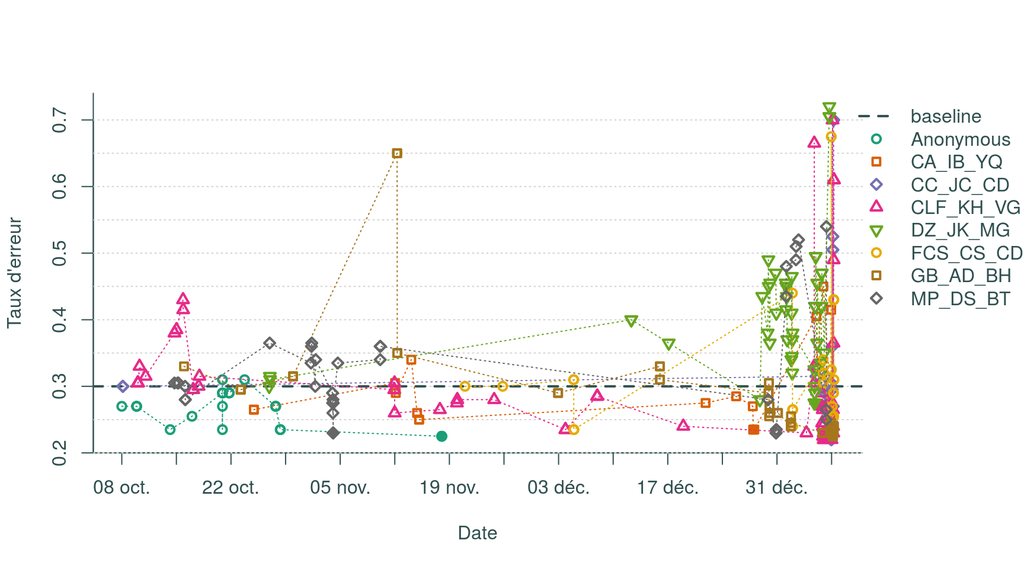

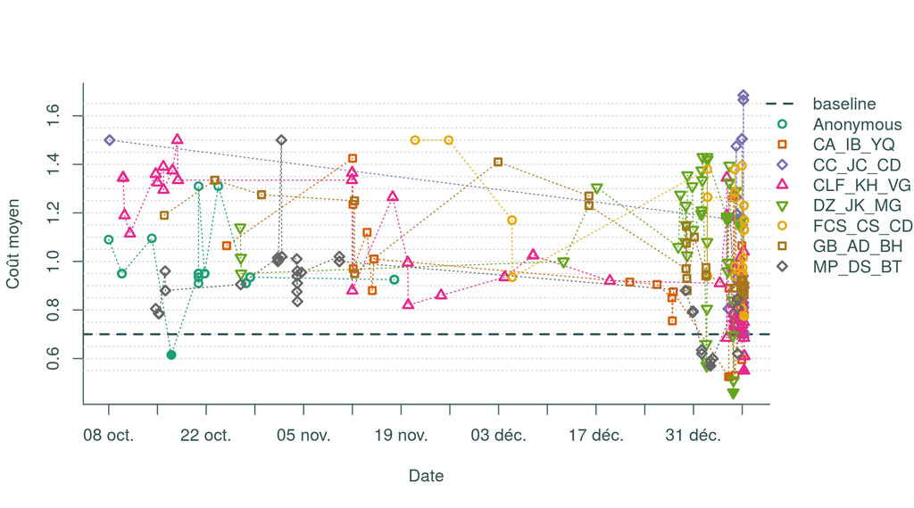

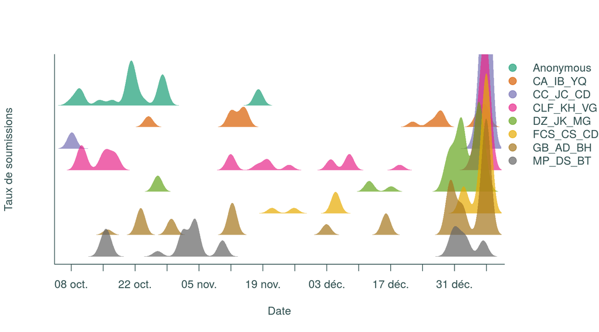

# Erreurs de lecture

| Equipe | Fichier | Message |
| --- | --- | --- |
| FCS_CS_CD | `my_pred6.csv` | `predictions contain missing values (NA)` |
| FCS_CS_CD | `my_pred7.csv` | `predictions contain missing values (NA)` |
| FCS_CS_CD | `Rpart.csv` | `predictions contain missing values (NA)` |
| MP_DS_BT | `my_pred.csv` | `submitted after the deadline` |

Développé avec [rchallenge](http://adrtod.github.io/rchallenge/).